# ARDL (AutoRegressive Distributed Lag)

Charbel MAMLANKOU - Silas HOUESSOU

```r
#Jeu de données

data(denmark)
head(denmark)
```

```
             LRM      LRY        LPY       IBO    IDE
1974 Q1 11.63255 5.903658 -0.6187359 0.1547356 0.0940
1974 Q2 11.60415 5.873820 -0.5807479 0.1779912 0.0955
1974 Q3 11.58152 5.837818 -0.5428478 0.1705647 0.0955
1974 Q4 11.60185 5.812255 -0.5046041 0.1522273 0.0955
1975 Q1 11.58630 5.803945 -0.4864585 0.1342276 0.0885
1975 Q2 11.60450 5.786761 -0.4544386 0.1334805 0.0790
```

```r
LRM = denmark$LRM
LRY = denmark$LRY
IBO = denmark$IBO
LPY = denmark$LPY
IDE = denmark$IDE
```

```r
# Visualisation des séries temporelles

par(mfrow=c(2,3))
plot.ts(LRM)
plot.ts(LRY)
```

```r
plot.ts(IBO)
plot.ts(LPY)
```

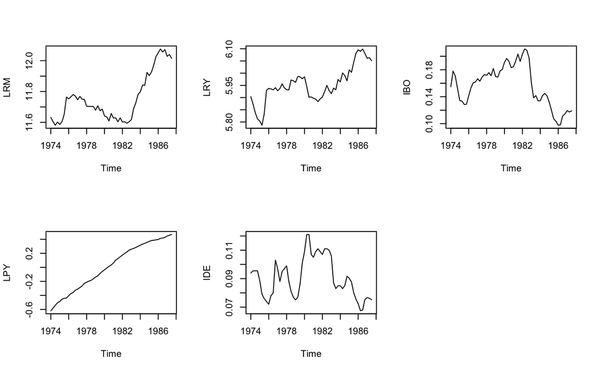

```r
plot.ts(IDE)
```

On pourrais tout de suite soupçonner une non stationnarité des séries LRM, LRY, IDE et IBO.

Pour en être sûr passons aux tests de stationnarité

```r
# Test de stationnarité -- Dickey Fuller Augmenté
print("LRM")
```

```
[1] "LRM"
```

```r
adf.test(LRM)
```

```
    Augmented Dickey-Fuller Test

data:  LRM
Dickey-Fuller = -1.4882, Lag order = 3, p-value = 0.7808
alternative hypothesis: stationary
```

```r
adf.test(diff(LRM))
```

```
    Augmented Dickey-Fuller Test

data:  diff(LRM)
Dickey-Fuller = -2.0904, Lag order = 3, p-value = 0.5381
alternative hypothesis: stationary
```

```r
print("LRY")
```

```
[1] "LRY"
```

```r
adf.test(LRY)
```

```
    Augmented Dickey-Fuller Test

data:  LRY
Dickey-Fuller = -2.6695, Lag order = 3, p-value = 0.3048
alternative hypothesis: stationary
```

```r
adf.test(diff(LRY))
```

```
    Augmented Dickey-Fuller Test

data:  diff(LRY)
Dickey-Fuller = -4.1797, Lag order = 3, p-value = 0.01
alternative hypothesis: stationary
```

```r
print("IBO")
```

```
[1] "IBO"
```

```r
adf.test(IBO)
```

```
    Augmented Dickey-Fuller Test

data:  IBO
Dickey-Fuller = -1.7639, Lag order = 3, p-value = 0.6697
alternative hypothesis: stationary
```

```r
adf.test(diff(IBO))
```

```
    Augmented Dickey-Fuller Test

data:  diff(IBO)
Dickey-Fuller = -4.2915, Lag order = 3, p-value = 0.01
alternative hypothesis: stationary
```

```r
print("LPY")
```

```
[1] "LPY"
```

```r
adf.test(LPY)
```

```
    Augmented Dickey-Fuller Test

data:  LPY
Dickey-Fuller = 0.52014, Lag order = 3, p-value = 0.99
alternative hypothesis: stationary
```

```r
adf.test(diff(LPY))
```

```
    Augmented Dickey-Fuller Test

data:  diff(LPY)
Dickey-Fuller = -2.8628, Lag order = 3, p-value = 0.227
alternative hypothesis: stationary
```

```r
adf.test(diff(diff(LPY)))
```

```
    Augmented Dickey-Fuller Test

data:  diff(diff(LPY))
Dickey-Fuller = -4.8714, Lag order = 3, p-value = 0.01
alternative hypothesis: stationary
```

```r
print("IDE")
```

```
[1] "IDE"
```

```r
adf.test(IDE)
```

```
    Augmented Dickey-Fuller Test

data:  IDE
Dickey-Fuller = -2.1932, Lag order = 3, p-value = 0.4967
alternative hypothesis: stationary
```

```r
adf.test(diff(IDE))
```

```
    Augmented Dickey-Fuller Test

data:  diff(IDE)
Dickey-Fuller = -4.0021, Lag order = 3, p-value = 0.0161
alternative hypothesis: stationary
```

**Test de stationnarité**

Passons à présent à la détermination des ordres d’intégration de ces séries

```r
# Ordre d'intégration -- package forecast

ndiffs(LRM)
```

```
[1] 1
```

```r
ndiffs(LRY)
```

```
[1] 1
```

```r
ndiffs(IBO)
```

```
[1] 1
```

```r
ndiffs(LPY)
```

```
[1] 2
```

```r
ndiffs(IDE)
```

```
[1] 0
```

On remarque que les séries (LRM, LRY et IBO) $\rightsquigarrow$ I(1), LRP $\rightsquigarrow$ I(2) et IDE $\rightsquigarrow$ I(0)

- Dans la suite du travail, nous avons choisi une illustration avec un modèle ayant pour variables explicatives, LRY, IBO et IDE. Notons que la même étude peut être faite sur l’ensemble des variables présentes dans le jeu de données

```r
# Modèle ARDL avec un ordre max = 5

models <- auto_ardl(LRM ~ LRY + IBO + IDE, data = denmark, max_order = 5)
models$top_orders
```

| LRM | LRY | IBO | IDE | AIC |
| --- | --- | --- | --- | --- |
| 3 | 1 | 3 | 2 | -251.0259 |
| 3 | 1 | 3 | 3 | -250.1144 |
| 2 | 2 | 0 | 0 | -249.6266 |
| 3 | 2 | 3 | 2 | -249.1087 |
| 3 | 2 | 3 | 3 | -248.1858 |
| 2 | 2 | 0 | 1 | -247.7786 |
| 2 | 1 | 0 | 0 | -247.5643 |
| 2 | 2 | 1 | 1 | -246.6885 |
| 3 | 3 | 3 | 3 | -246.3061 |
| 2 | 2 | 1 | 2 | -246.2709 |

[output cut: 10 more lines]

On obtient dans ce tableau les 20 meilleures combinaisons des ordres pour le modèle ARDL déployé

```r
# Obtention du meilleur modèle

ardl_3132 <- models$best_model
ardl_3132$order
```

```
LRM LRY IBO IDE
  3   1   3   2
```

Il convient donc de choisir le modèle ARDL(3,1,3,2) du fait qu’il minimise le critère d’information AIC (-251.0259)

```r
summary(ardl_3132)
```

```
Time series regression with "zooreg" data:
Start = 1974 Q4, End = 1987 Q3

Call:
dynlm::dynlm(formula = full_formula, data = data, start = start,
    end = end)

Residuals:
      Min        1Q    Median        3Q       Max
-0.029939 -0.008856 -0.002562  0.008190  0.072577

Coefficients:
            Estimate Std. Error t value Pr(>|t|)
(Intercept)   2.6202     0.5678   4.615 4.19e-05 ***
L(LRM, 1)     0.3192     0.1367   2.336 0.024735 *
L(LRM, 2)     0.5326     0.1324   4.024 0.000255 ***
L(LRM, 3)    -0.2687     0.1021  -2.631 0.012143 *
LRY           0.6728     0.1312   5.129 8.32e-06 ***
L(LRY, 1)    -0.2574     0.1472  -1.749 0.088146 .
IBO          -1.0785     0.3217  -3.353 0.001790 **
L(IBO, 1)    -0.1062     0.5858  -0.181 0.857081
L(IBO, 2)     0.2877     0.5691   0.505 0.616067
L(IBO, 3)    -0.9947     0.3925  -2.534 0.015401 *
IDE           0.1255     0.5545   0.226 0.822161
L(IDE, 1)    -0.3280     0.7213  -0.455 0.651847
L(IDE, 2)     1.4079     0.5520   2.550 0.014803 *
---
Signif. codes:  0 ‘***’ 0.001 ‘**’ 0.01 ‘*’ 0.05 ‘.’ 0.1 ‘ ’ 1

Residual standard error: 0.0191 on 39 degrees of freedom
Multiple R-squared:  0.988, Adjusted R-squared:  0.9843
F-statistic: 266.8 on 12 and 39 DF,  p-value: < 2.2e-16
```

On constate ici que les coefficients de L(LRY,1), L(IBO, 1), L(IBO, 2), IDE et L(IDE,1) ne sont pas significatifs au seuil de 5%.

```r
adf.test(ardl_3132$residuals)
```

```
    Augmented Dickey-Fuller Test

data:  ardl_3132$residuals
Dickey-Fuller = -4.0877, Lag order = 3, p-value = 0.01258
alternative hypothesis: stationary
```

On obtient p-value < 0.05 alors l’hypothèse nulle selon laquelle il n’y aurait pas une stationnarité des résidus est rejetée

```r
# Test de normalité des résidus

jarque.bera.test(ardl_3132$residuals)
```

```
    Jarque Bera Test

data:  ardl_3132$residuals
X-squared = 85.239, df = 2, p-value < 2.2e-16
```

On obtient p-value < 0.05 alors l’hypothèse nulle est rejetée. Il n’y a donc pas normalité des résidus

```r
# Test d'autocorrelation des résidus

bgtest(ardl_3132)
```

```
    Breusch-Godfrey test for serial correlation of order up to 1

data:  ardl_3132
LM test = 1.1192, df = 1, p-value = 0.2901
```

Test de Breush-Godfrey

p-value > 0.05 alors on ne peut rejeter l’hyothèse nulle selon laquelle il y aurait absence d’autocorrelation

```r
# Hétéroscédasticité - TEST ARCH

ArchTest(ardl_3132$residuals)
```

```
    ARCH LM-test; Null hypothesis: no ARCH effects

data:  ardl_3132$residuals
Chi-squared = 2.7959, df = 12, p-value = 0.9968
```

On obtient p-value > 0.05 alors l’hypothèse nulle selon laquelle il y aurait homoscédasticité ne peut être rejetée

```r
# bounds F-test -- cointégration aux bornes

tbounds = bounds_f_test(ardl_3132, case = 2, alpha = 0.05)
tbounds$tab
```

|  | statistic | Lower-bound I(0) | Upper-bound I(1) | alpha | p.value |
| --- | --- | --- | --- | --- | --- |
| F | 5.116768 | 2.77498 | 3.65953 | 0.05 | 0.004417563 |

```r
NA
```

p-value = 0.004417563 (< 0.05) alors $H_0$ est rejetée

```r
tbounds$alternative
```

```
[1] "Possible cointegration"
```

```r
tbounds$method
```

```
[1] "Bounds F-test (Wald) for no cointegration"
```

```r
# Dyanamique de court et de long terme

multipliers(ardl_3132, type = "sr") # relation à court terme
```

|  | Term | Estimate | Std. Error | t value | Pr(>\|t\|) |
| --- | --- | --- | --- | --- | --- |
| 1 | (Intercept) | 2.6201916 | 0.5677679 | 4.6148990 | 4.186867e-05 |
| 2 | LRY | 0.6727993 | 0.1311638 | 5.1294603 | 8.317401e-06 |
| 3 | IBO | -1.0785180 | 0.3217011 | -3.3525465 | 1.790030e-03 |
| 4 | IDE | 0.1254643 | 0.5544522 | 0.2262852 | 8.221614e-01 |

```r
multipliers(ardl_3132) # relation à long terme -- type = 'lr' (default)
```

|  | Term | Estimate | Std. Error | t value | Pr(>\|t\|) |
| --- | --- | --- | --- | --- | --- |
| 1 | (Intercept) | 6.2856579 | 0.7719160 | 8.142930 | 6.107445e-10 |
| 2 | LRY | 0.9964676 | 0.1239310 | 8.040503 | 8.358472e-10 |
| 3 | IBO | -4.5381160 | 0.5202961 | -8.722180 | 1.058619e-10 |
| 4 | IDE | 2.8915201 | 0.9950853 | 2.905801 | 6.009239e-03 |

- sr = short-run
- lr = long-run

```r
# Forecasting

ardl_3132_lm <- to_lm(ardl_3132)
insample_data <- ardl_3132$model
predicted_values <- predict(ardl_3132_lm, newdata = insample_data)
insample_data
```

|  | LRM | L(LRM, 1) | L(LRM, 2) | L(LRM, 3) | LRY | L(LRY, 1) | IBO | L(IBO, 1) | L(IBO, 2) | L(IBO, 3) | IDE | L(IDE, 1) | L(IDE, 2) |
| --- | --- | --- | --- | --- | --- | --- | --- | --- | --- | --- | --- | --- | --- |
| 1974 Q4 | 11.60185 | 11.58152 | 11.60415 | 11.63255 | 5.812255 | 5.837818 | 0.1522273 | 0.1705647 | 0.1779912 | 0.1547356 | 0.09550000 | 0.09550000 | 0.09550000 |
| 1975 Q1 | 11.58630 | 11.60185 | 11.58152 | 11.60415 | 5.803945 | 5.812255 | 0.1342276 | 0.1522273 | 0.1705647 | 0.1779912 | 0.08850000 | 0.09550000 | 0.09550000 |
| 1975 Q2 | 11.60450 | 11.58630 | 11.60185 | 11.58152 | 5.786761 | 5.803945 | 0.1334805 | 0.1342276 | 0.1522273 | 0.1705647 | 0.07900000 | 0.08850000 | 0.09550000 |
| 1975 Q3 | 11.65331 | 11.60450 | 11.58630 | 11.60185 | 5.833412 | 5.786761 | 0.1284132 | 0.1334805 | 0.1342276 | 0.1522273 | 0.07600000 | 0.07900000 | 0.08850000 |
| 1975 Q4 | 11.76425 | 11.65331 | 11.60450 | 11.58630 | 5.929849 | 5.833412 | 0.1288357 | 0.1284132 | 0.1334805 | 0.1342276 | 0.07400000 | 0.07600000 | 0.07900000 |
| 1976 Q1 | 11.75293 | 11.76425 | 11.65331 | 11.60450 | 5.937654 | 5.929849 | 0.1413445 | 0.1288357 | 0.1284132 | 0.1334805 | 0.07200000 | 0.07400000 | 0.07600000 |
| 1976 Q2 | 11.76548 | 11.75293 | 11.76425 | 11.65331 | 5.935332 | 5.937654 | 0.1531187 | 0.1413445 | 0.1288357 | 0.1284132 | 0.07800000 | 0.07200000 | 0.07400000 |
| 1976 Q3 | 11.78058 | 11.76548 | 11.75293 | 11.76425 | 5.931755 | 5.935332 | 0.1605787 | 0.1531187 | 0.1413445 | 0.1288357 | 0.08000000 | 0.07800000 | 0.07200000 |
| 1976 Q4 | 11.77018 | 11.78058 | 11.76548 | 11.75293 | 5.940524 | 5.931755 | 0.1618325 | 0.1605787 | 0.1531187 | 0.1413445 | 0.10300000 | 0.08000000 | 0.07800000 |
| 1977 Q1 | 11.74589 | 11.77018 | 11.78058 | 11.76548 | 5.928044 | 5.940524 | 0.1665814 | 0.1618325 | 0.1605787 | 0.1531187 | 0.09700000 | 0.10300000 | 0.08000000 |

[output cut: 42 more lines]

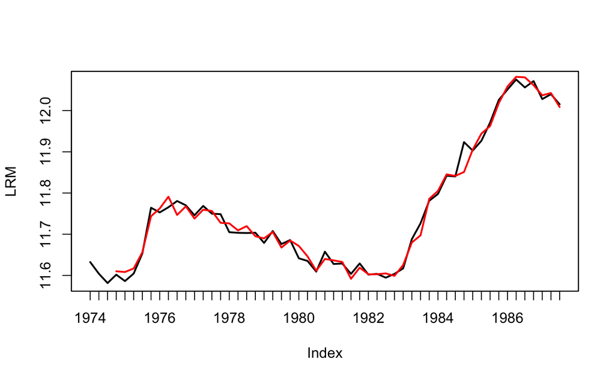

```r
predicted_values <- ts(predicted_values, start = c(1974,4), frequency=4)
plot(LRM, lwd=2) # var dependante
lines(predicted_values, col="red", lwd=2)
```